# What Porpotion of UOA Students Enagage in Reading and How Can That Relate to IQ?

# Introduction

*I have taken an observation survey to where I observed the number of students reading books and asked how important reading is to them, if they read in their free time and what their IQ was. This survey was taken over the course of 2 days where I had asked 20 on March 31st 2025 and 20 on May 7th 2025.*

## Plot 1 - Impact vs. IQ

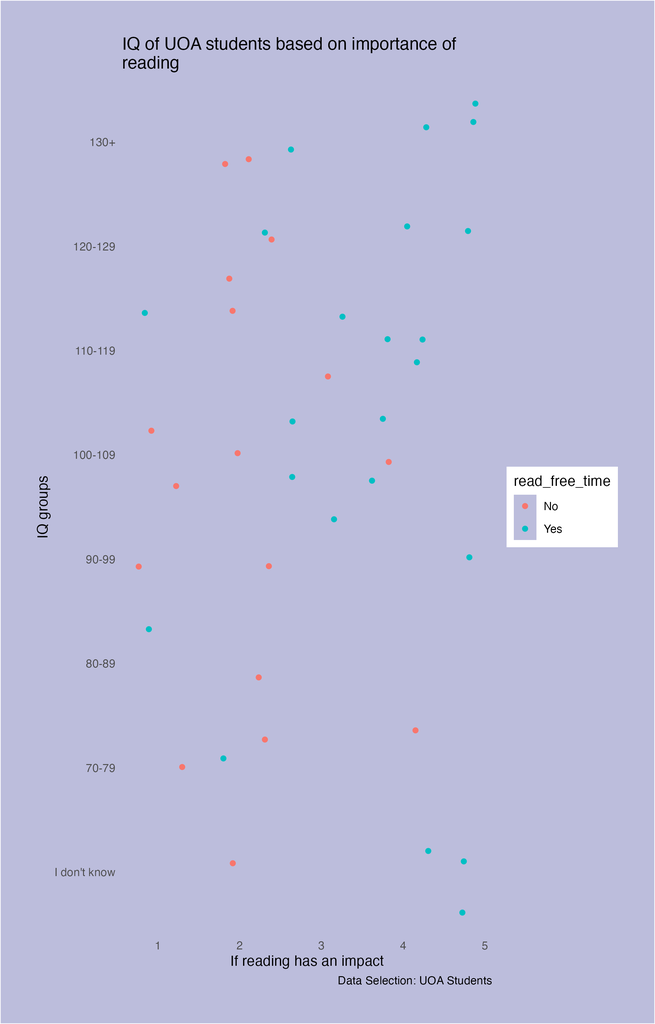